# IODS course project

# Chapter 3

## Logistic Regression and cross validation

Link to IODS repository: https://github.com/dawit2010/IODS-project

In this chapter, we have looked at building and validating logistic regression models using R. Specifically, we build a logistic regression model using which the relationship between explanatory variables and a binary target variable is modeled.

#### Data wrangling

We first preprocessed the raw data found [here](https://archive.ics.uci.edu/ml/datasets/Student+Performance) by combining two datasets, and some of their variables. The details of how this is done including the R commands used can be found [here](https://github.com/Dawit2010/IODS-project/blob/master/data/create_alc.R). The analysis dataset after this data wrangling step ready for further analysis can be found [here](https://github.com/Dawit2010/IODS-project/blob/master/data/alcData.txt)

#### Logistic regression analysis

- Reading in data

We read in the analysis ready dataset that we prepared (as described above):

```r
alcData <- read.table("data/alcData.txt",header=T, sep="\t")
```

and print the names of the variales. The data presents student achievement in maths and portugese in two secondary education portugese schools. The two datasets are combined using inner join, and some variables e.g grades are averaged from the two subject for each students. Our focus on alcohol consumption among the students.

```r
colnames(alcData)
```

```
##  [1] "school"     "sex"        "age"        "address"    "famsize"
##  [6] "Pstatus"    "Medu"       "Fedu"       "Mjob"       "Fjob"
## [11] "reason"     "nursery"    "internet"   "guardian"   "traveltime"
## [16] "studytime"  "failures"   "schoolsup"  "famsup"     "paid"
## [21] "activities" "higher"     "romantic"   "famrel"     "freetime"
## [26] "goout"      "Dalc"       "Walc"       "health"     "absences"
## [31] "G1"         "G2"         "G3"         "alc_use"    "high_use"
```

```r
dim(alcData)
```

```
## [1] 382  35
```

- Prior hypothesis regarding high alcohol use

I would assume that high/low alcohol usage among students would be strongly related to sex (men drinking more than women), age (higher alcohol consumption among older students), studytime (low amount of study time related to higher alcohol use),absences(more absent students drink more). We will test this hypothesis below.

- Exploration of the chosen variables

```r
library(dplyr)
library(ggplot2)

str(alcData)
```

```
## 'data.frame':    382 obs. of  35 variables:
##  $ school    : Factor w/ 2 levels "GP","MS": 1 1 1 1 1 1 1 1 1 1 ...
##  $ sex       : Factor w/ 2 levels "F","M": 1 1 1 1 1 2 2 1 2 2 ...
##  $ age       : int  18 17 15 15 16 16 16 17 15 15 ...
##  $ address   : Factor w/ 2 levels "R","U": 2 2 2 2 2 2 2 2 2 2 ...
##  $ famsize   : Factor w/ 2 levels "GT3","LE3": 1 1 2 1 1 2 2 1 2 1 ...
##  $ Pstatus   : Factor w/ 2 levels "A","T": 1 2 2 2 2 2 2 1 1 2 ...
##  $ Medu      : int  4 1 1 4 3 4 2 4 3 3 ...
##  $ Fedu      : int  4 1 1 2 3 3 2 4 2 4 ...
##  $ Mjob      : Factor w/ 5 levels "at_home","health",..: 1 1 1 2 3 4 3 3 4 3 ...
##  $ Fjob      : Factor w/ 5 levels "at_home","health",..: 5 3 3 4 3 3 3 5 3 3 ...
##  $ reason    : Factor w/ 4 levels "course","home",..: 1 1 3 2 2 4 2 2 2 2 ...
##  $ nursery   : Factor w/ 2 levels "no","yes": 2 1 2 2 2 2 2 2 2 2 ...
##  $ internet  : Factor w/ 2 levels "no","yes": 1 2 2 2 1 2 2 1 2 2 ...
##  $ guardian  : Factor w/ 3 levels "father","mother",..: 2 1 2 2 1 2 2 2 2 2 ...
```

[output cut: 21 more lines]

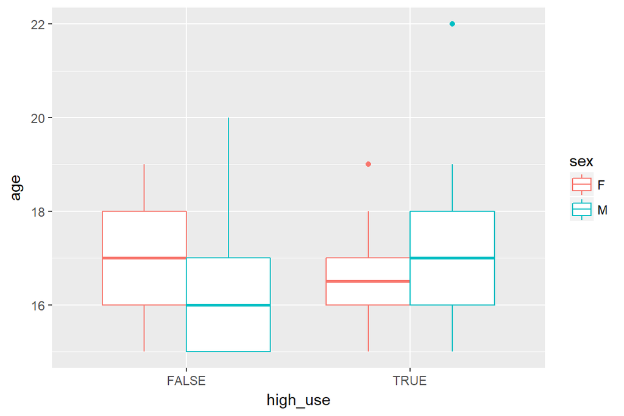

```r
par(mfrow = c(2,2))

# draw a boxplots
g1 <- ggplot(alcData, aes(x = high_use, y = age,col=sex))
g1 + geom_boxplot()
```

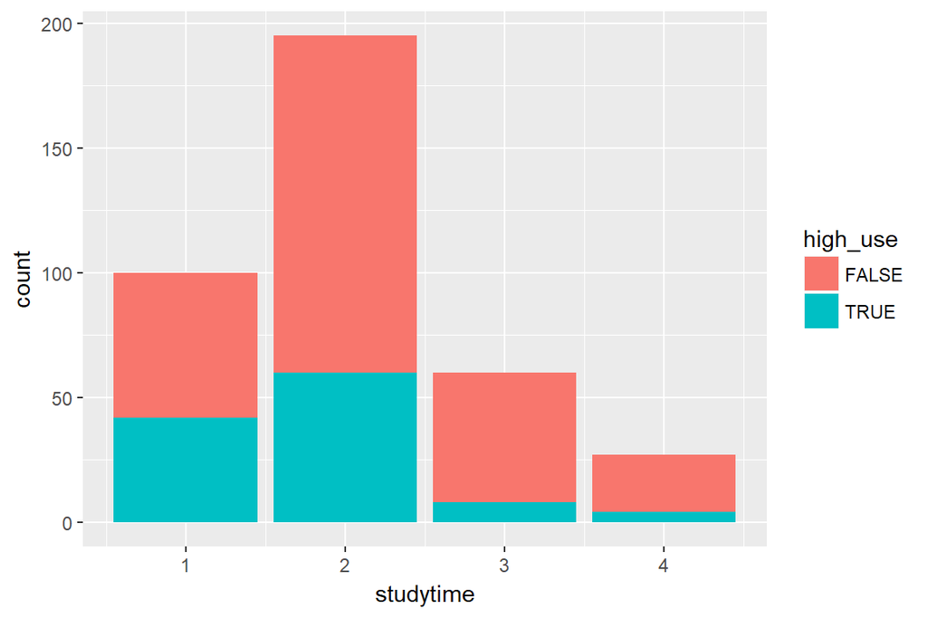

```r
g2 <- ggplot(alcData, aes(x = studytime,fill=high_use))
g2 + geom_bar()
```

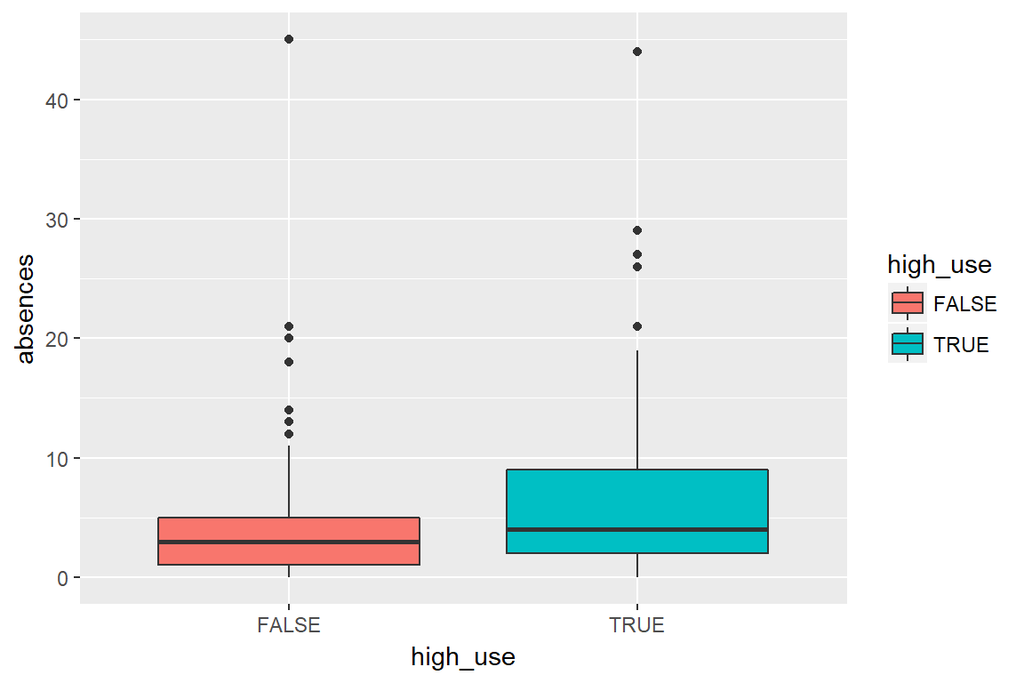

```r
g3 <- ggplot(alcData, aes(x = high_use,y = absences, fill = high_use))
g3 + geom_boxplot()
```